# edgeR-limma workflow (TCGA RNA-seq data)

Jing Zhang

2022/01 - 2022/02

## 1 数据来源

- TCGA数据库RNA-Seq表达信息 [merge_HTSeq_count.txt]
- TCGA数据库样本信息 [sample_barcode.txt]

## 2 数据处理思路

- RNA-Seq typical analysis : raw data pre-processing, exploratory data analysis, differential expression (DE) testing and pathway analysis with the results obtained informing future experiments and validation studies.
- here limma (voom method, linear modelling, empirical Bayes moderation) and edgeR package used for differential expression testing.

## 3 参考文献

- Wu B, Xi S. Bioinformatics analysis of differentially expressed genes and pathways in the development of cervical cancer. BMC Cancer. 2021;21(1):1-15. doi:10.1186/s12885-021-08412-4
- Liu J, Nie S, Gao M, et al. Identification of EPHX2 and RMI2 as two novel key genes in cervical squamous cell carcinoma by an integrated bioinformatic analysis. J Cell Physiol. 2019;234(11):21260-21273. doi:10.1002/jcp.28731
- Robinson MD, McCarthy DJ, Smyth GK. edgeR: a Bioconductor package for differential expression analysis of digital gene expression data. Bioinformatics. 2010 Jan 1;26(1):139-40. doi: 10.1093/bioinformatics/btp616. Epub 2009 Nov 11. PMID: 19910308; PMCID: PMC2796818.
- Ritchie ME, Phipson B, Wu D, Hu Y, Law CW, Shi W, Smyth GK. limma powers differential expression analyses for RNA-sequencing and microarray studies. Nucleic Acids Res. 2015 Apr 20;43(7):e47. doi: 10.1093/nar/gkv007. Epub 2015 Jan 20. PMID: 25605792; PMCID: PMC4402510.
- Huber W, Carey VJ, Gentleman R, Anders S, Carlson M, Carvalho BS, Bravo HC, Davis S, Gatto L, Girke T, Gottardo R, Hahne F, Hansen KD, Irizarry RA, Lawrence M, Love MI, MacDonald J, Obenchain V, Oleś AK, Pagès H, Reyes A, Shannon P, Smyth GK, Tenenbaum D, Waldron L, Morgan M. Orchestrating high-throughput genomic analysis with Bioconductor. Nat Methods. 2015 Feb;12(2):115-21. doi: 10.1038/nmeth.3252. PMID: 25633503; PMCID: PMC4509590.

## 4 Load packages

## 5 Results and plots

### 5.1 Read input files

-读取TCGA count [merge_HTSeq_count]数据，通过样本信息列表[sample_barcode.txt]对不同癌种数据进行过滤，依据sample TCGA 命名规则对正常组织和肿瘤组织进行区分  
-肺癌患者包含了LUAD和LUSC两种类型,肺癌数据分析有两条路线：  
1) 方案一不对亚型进行区分，寻找正常组织和肿瘤组织显著差异表达基因 （为本workflow展示流程）  
2) 方案二对亚型进行区分，分别找到每个亚型中高表达和低表达基因，对两种亚型取交集得到最终结果

#### read in count-data and filter (method 1, saved into TCGA_lung.RData)

```
# read TCGA count data
DF <- read.table("C:/Users/zhang.jing/OneDrive/! Production/TCGA/merge_HTSeq_count/merge_HTSeq_count.txt", sep='\t', header=TRUE, row.names=1, stringsAsFactors = FALSE)
DF <- DF[-nrow(DF), ]

# filter lung cancer
AB <- read_table2("merge_HTSeq_count/sample_barcode.txt")
ab <- AB[sapply('ung', grepl, AB$primary_site),] # 1145

# extract only lung cancer
dft$sample <- rownames(dft)
dft$sample <- gsub('[.]','-',dft$sample)
rownames(dft) <- dft$sample
dft <- dft[dft$sample %in% ab$case_id,]  # 1145 samples of lung cancer

# add group(tumor or normal tissue) information
dft<-dft %>% separate(sample, c("TCGA", "TSS Code", "participant", "sample","portion", "plate", "center"), "-")
dft$sample <- gsub('[A-Z]','',dft$sample)
dft$sample <- as.numeric(dft$sample)
dft[dft$sample<10,]$sample <- rep('tumor', length(dft[dft$sample<10,]$sample) )
dft[which(dft$sample>=10 & dft$sample<=29) ,]$sample <- rep('normal', length(dft[which(dft$sample>=10 & dft$sample<=29) ,]$sample))

dft$sample<-as.factor(dft$sample)
dft<-dft[order(dft$sample,decreasing = FALSE),]

tem <-dft %>% select(-contains(c('TCGA','TSS Code','participant','sample','portion','plate','center')))
df <- as.data.frame(t(tem))

summary(as.factor(dft$sample)) # tumor 1037 normal 108
```

#### read in count-data and filter (method 2, saved into TCGA_lung.RData)

```
# read TCGA count data
ab1 <- AB[sapply('TCGA-LUAD', grepl, AB$project_id),] # 594
ab2 <- AB[sapply('TCGA-LUSC', grepl, AB$project_id),] # 551

dft1 <- dft[rownames(dft) %in% ab1$case_id,]  # 594 samples of lung cancer
dft2 <- dft[rownames(dft) %in% ab2$case_id,] # 551 samples of lung cancer
tem1 <-dft1 %>% select(-contains(c('TCGA','TSS Code','participant','sample','portion','plate','center')))
df1 <- as.data.frame(t(tem1))
tem2 <-dft2 %>% select(-contains(c('TCGA','TSS Code','participant','sample','portion','plate','center')))
df2 <- as.data.frame(t(tem2))


# test
dft<-dft1
df<-df1
```

### 5.2. Making a count matrix, normalization and filtering

- 对矩阵进行归一化等处理

#### filtering and normalization

```r
load("C:/Users/zhang.jing/OneDrive/! Production/TCGA/TCGA_lung.RData")


# create a DGEList object
dge <- DGEList(counts=df, group=group_list)
print(paste('initial data dimention: ', dim(dge)[1], 'x', dim(dge)[2])) # 60482 transcripts, 1145 samples
```

```
## [1] "initial data dimention:  60482 x 1145"
```

```r
lcpm1 <- cpm(dge, log=TRUE) # converting to the log2-scale (normalization step, for plot)

# check transcipts with low counts
print(paste(table(rowSums(dge$counts==0)==1145)[2],'transcipts with low counts, will be filtered'))  # 2158 transcripts have zero counts across all samples
```

```
## [1] "2158 transcipts with low counts, will be filtered"
```

```r
L <- mean(dge$samples$lib.size) * 1e-6 #average library size
M <- median(dge$samples$lib.size) * 1e-6

# remove transcript/gene that consistently have zero or very low counts
keep <- filterByExpr(dge, group_list) # keep CPM >0.2 in at leasAt three samples
dge <- dge[keep,,keep.lib.sizes=FALSE]
print(paste('filtered data dimention: ', dim(dge)[1], 'x', dim(dge)[2])) # 27753 transcripts, 1145 samples
```

```
## [1] "filtered data dimention:  27753 x 1145"
```

```r
#### normalization
lcpm2 <- cpm(dge, log=TRUE) # converting to the log2-scale
```

#### plot and compare filtered data

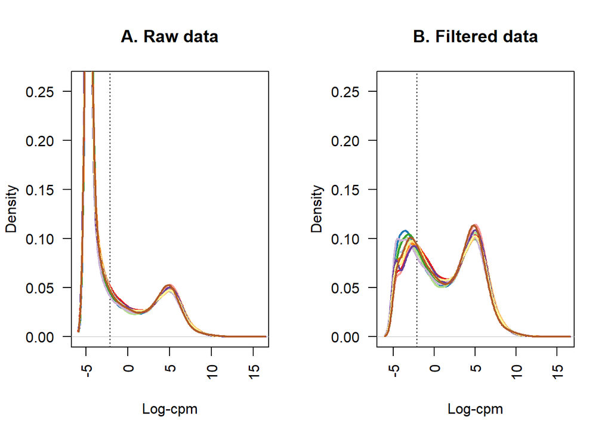

```r
# density plot before and after filter
lcpm.cutoff <- log2(10/M + 2/L)
nsamples <- ncol(dge)
col <- brewer.pal(nsamples, "Paired")
par(mfrow=c(1,2))

plot(density(lcpm1[,1]), col=col[1], lwd=2, ylim=c(0,0.26), las=2, main="", xlab="")
title(main="A. Raw data", xlab="Log-cpm")
abline(v=lcpm.cutoff, lty=3)

for (i in 2:nsamples){
  den <- density(lcpm1[,i])
  lines(den$x, den$y, col=col[i], lwd=2)}

plot(density(lcpm2[,1]), col=col[1], lwd=2, ylim=c(0,0.26), las=2, main="", xlab="")
title(main="B. Filtered data", xlab="Log-cpm")
abline(v=lcpm.cutoff, lty=3)

for (i in 2:nsamples){
  den <- density(lcpm2[,i])
  lines(den$x, den$y, col=col[i], lwd=2)}
```

#### normalization for composition bias: scale normalization using log-CPM (Counts Per Million)

```r
dge <- calcNormFactors(dge, method = "TMM")
head(dge$samples$norm.factors)
```

```
## [1] 0.8842078 0.7842848 0.9040507 0.8425325 1.0062370 1.0348320
```

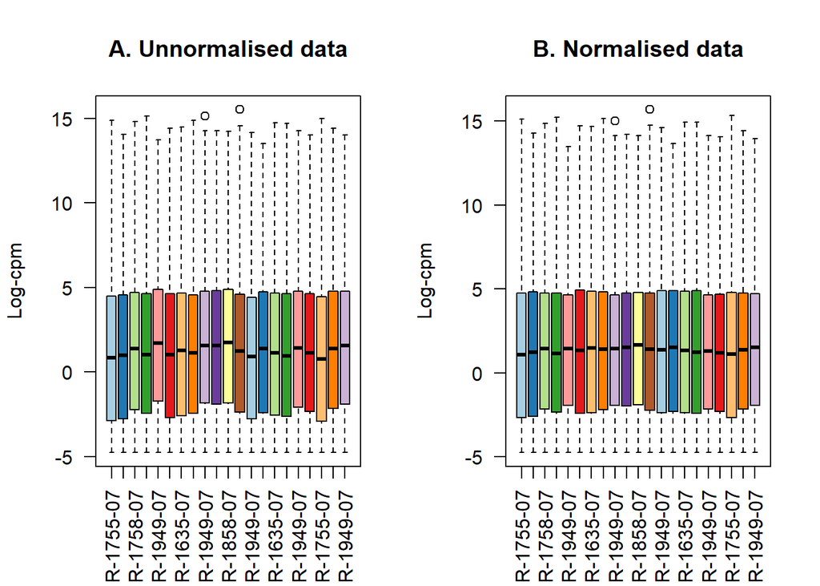

```r
lcpm3 <- cpm(dge, log=TRUE)

# plot
par(mfrow=c(1,2))
boxplot(lcpm2[,30:50], las=2, col=col, main="")
title(main="A. Unnormalised data",ylab="Log-cpm")
boxplot(lcpm3[,30:50], las=2, col=col, main="")
title(main="B. Normalised data",ylab="Log-cpm")
```

#### unsupervised clustering of samples

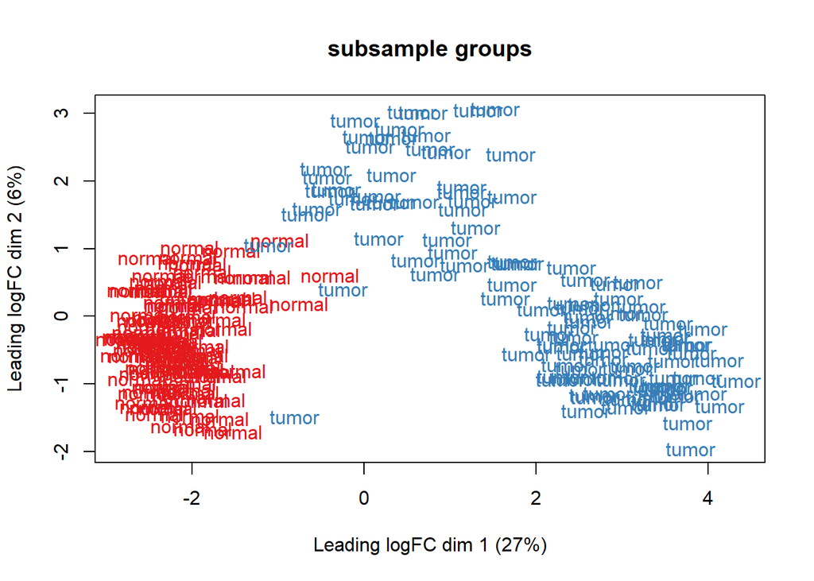

```r
col.group <- group_list[1:220]
levels(col.group) <-  brewer.pal(nlevels(col.group), "Set1")
col.group <- as.character(col.group)

plotMDS(lcpm3[,1:220], labels=group_list[1:220], col=col.group)
title(main="subsample groups")
```

### 5.3. Differential expression analysis

#### create design matrix and contrasts

```r
group_list <- factor(dft$sample)
design <- model.matrix(~0+group_list)
colnames(design) <- gsub("group_list", "", colnames(design))
rownames(design) <- colnames(df)


contr.matrix <- makeContrasts(
  tumorvsnormal = tumor-normal,
  levels = colnames(design))
contr.matrix
```

```
##         Contrasts
## Levels   tumorvsnormal
##   normal            -1
##   tumor              1
```

#### removing heteroscedascity from count data

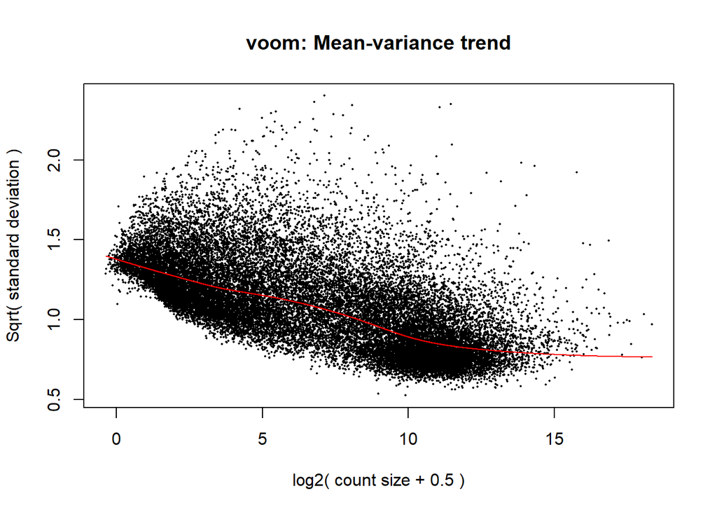

```r
# voom method (other method : treat )
v <- voom(dge, design, plot=TRUE)
```

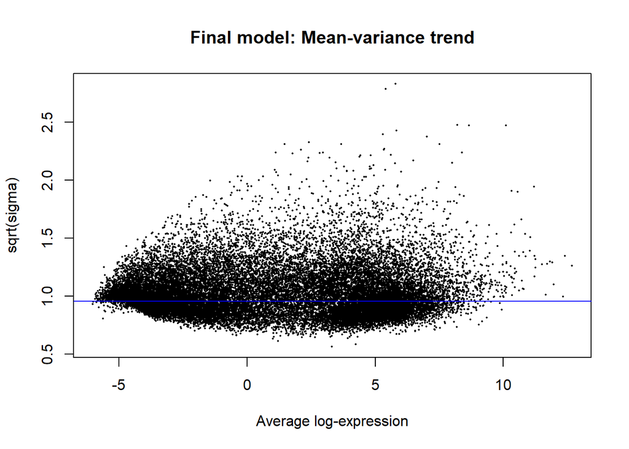

```r
fit  <- lmFit(v, design)
fit  <- contrasts.fit(fit, contrasts=contr.matrix)
efit <- eBayes(fit)

plotSA(efit, main="Final model: Mean-variance trend")
```

#### cutoff and save

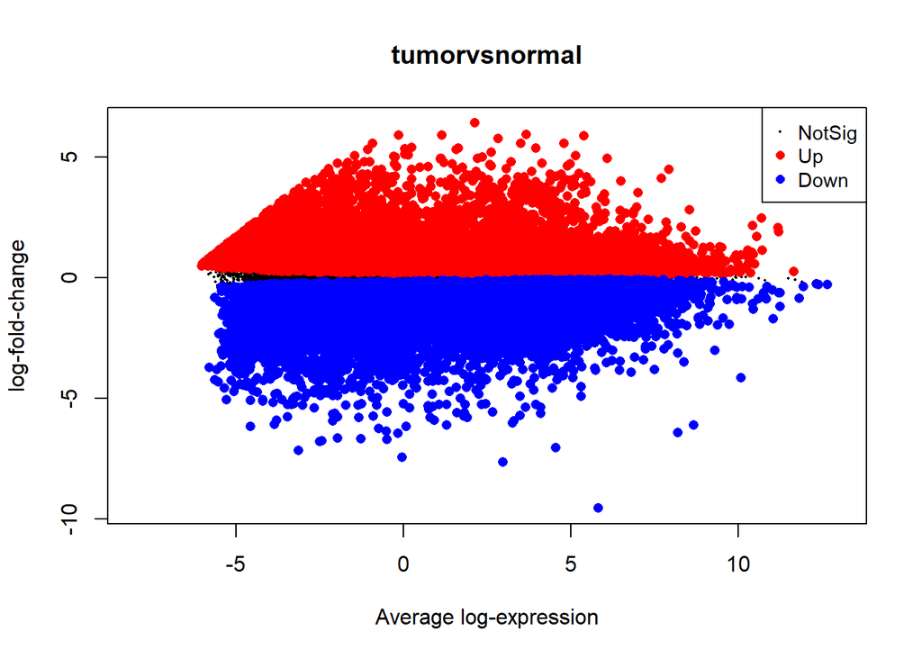

```r
plotMD(efit, column=1, status=decideTests(efit)[,1], main=colnames(efit)[1], xlim=c(-8,13))
```

```r
# check : Adjusted p value < 0.05 and |log2fold change (FC)| >2 as cutoff
summary(decideTests(efit,lfc=2,p.value = 0.05)) # 4013 up-regulated gene and 4525 down-regulated gene when using log2fold change (FC)| >1, 1184 up-regulated gene and 1793 down-regulated gene when using log2fold change (FC)| >2.
```

```
##        tumorvsnormal
## Down            1793
## NotSig         24776
## Up              1184
```

```r
# save
output<-topTable(efit, number =Inf, sort.by = "P") # 27753
output<-output[which(output$adj.P.Val < 0.05 & abs(output$logFC) > 2),] # 2977 DE genes
output<- output[order(output$P.Value, decreasing = FALSE),]

write.table(output, file="Lung_cancer_results/tumor_normal_efit_all.txt", sep='\t', row.names = FALSE, quote = FALSE)
```

#### add gene symbol

```r
lookup <- as.character(rownames(efit))
keytypes(org.Hs.eg.db)
```

```
##  [1] "ACCNUM"       "ALIAS"        "ENSEMBL"      "ENSEMBLPROT"  "ENSEMBLTRANS"
##  [6] "ENTREZID"     "ENZYME"       "EVIDENCE"     "EVIDENCEALL"  "GENENAME"
## [11] "GENETYPE"     "GO"           "GOALL"        "IPI"          "MAP"
## [16] "OMIM"         "ONTOLOGY"     "ONTOLOGYALL"  "PATH"         "PFAM"
## [21] "PMID"         "PROSITE"      "REFSEQ"       "SYMBOL"       "UCSCKG"
## [26] "UNIPROT"
```

```r
id<-bitr(lookup, fromType = "ENSEMBL", toType = c("ENTREZID","SYMBOL","GENENAME"), OrgDb = "org.Hs.eg.db")
#id <- AnnotationDbi::select(org.Hs.eg.db, keys = lookup, columns = c("SYMBOL", "ENTREZID","GENENAME"),keytype = "ENSEMBL")

output$ENSEMBL<-rownames(output)
output<-merge(output, id[!duplicated(id$ENSEMBL),], by='ENSEMBL', all.x=TRUE)
write.table(output, file="Lung_cancer_results/tumor_normal_efit_all.txt", sep='\t', row.names = FALSE, quote = FALSE)
```

#### plot and save

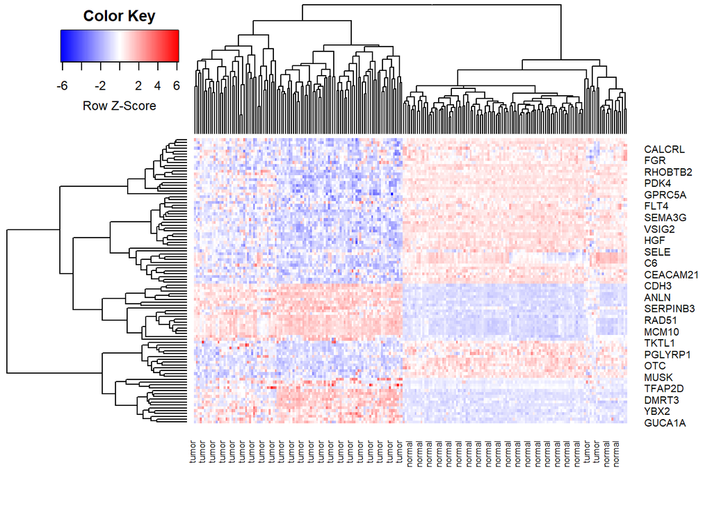

```r
i <- which(rownames(lcpm3) %in% output[1:100,1])
hm <- as.data.frame(lcpm3[i,])
hm$ENSEMBL<-rownames(hm)
hm<-merge(hm,output[,c(1,9)],by='ENSEMBL',all.x=TRUE)
hm<-hm[,-1]

#mycol <- colorpanel(1000,"blue","white","red")
heatmap.2(scale(hm[,1:220]), scale="row", labRow=hm$SYMBOL, labCol=group_list[1:220], col = bluered(100), trace = "none", density.info = "none")
```